# Introduction

```r
#devtools::install_github("kevincjnixon/BinfTools")
library(BinfTools)
```

# Usage

Ideally, we will be using objects created from DESeq2, but objects from other RNA-seq analysis packages can be modified to work as input for BinfTools. Here, we are using RNA-seq data from Nixon et al. (2019) comparing gene expression in the *Drosophila* musrhoom body between Wild-Type (expressing mCherry-shRNA) and Bap60 knockdown.

```r
###Load data generated from DESeq2:
head(norm_counts) #Normalized gene counts (from counts(dds, normalized=T))
```

```
#>                   mC_1        mC_2        mC_3       B60_1      B60_2
#> FBgn0000008 14919.5007 23183.73590 19569.22815 11179.14132 14068.5861
#> FBgn0000014   529.3257    27.68207   345.23983   644.51695   950.8071
#> FBgn0000015  1001.9762    55.36415   317.38186   504.13726   659.7274
#> FBgn0000017 19763.6333 23887.49936 24366.76835 21539.57193 21727.0212
#> FBgn0000018   153.9857    95.82256    17.90869    94.26957   135.9438
#> FBgn0000024 33611.6504 33993.58529 33080.34302 36574.54357 28803.2969
```

```r
head(res) #Results object (from as.data.frame(results(dds, contrast=c("Condition","WT","KO"))))
```

```
#>                baseMean log2FoldChange     lfcSE       stat      pvalue
#> FBgn0000008 16584.03843    -0.60670534 0.1994743 -3.0415214 0.002353858
#> FBgn0000014   499.51433     1.40727447 0.8798824  1.5993893 0.109734130
#> FBgn0000015   507.71737     0.34488755 0.8811641  0.3913999 0.695501674
#> FBgn0000017 22256.89883    -0.06770743 0.1336063 -0.5067683 0.612317420
#> FBgn0000018    99.58606     0.36807679 1.0780470  0.3414293 0.732780444
#> FBgn0000024 33212.68383    -0.03807819 0.1322525 -0.2879205 0.773407632
#>                   padj
#> FBgn0000008 0.02004494
#> FBgn0000014 0.31988301
#> FBgn0000015 0.86736891
#> FBgn0000017 0.82154833
#> FBgn0000018         NA
#> FBgn0000024 0.90830459
```

```r
print(cond) #Character vector of conditions (from as.character(dds$Condition))
```

```
#> [1] "WT" "WT" "WT" "KO" "KO"
```

```r
print(geneSet) #List of gene sets related to rhodopsin signaling imported from qusage::read.gmt("rhodopsin.gmt")
```

```
#> $deactivation_of_rhodopsin_mediated_signaling
#>  [1] "FBgn0004784" "FBgn0003218" "FBgn0287478" "FBgn0000253" "FBgn0000120"
#>  [6] "FBgn0086704" "FBgn0004623" "FBgn0261549" "FBgn0030555" "FBgn0004435"
#> [11] "FBgn0262738" "FBgn0015721" "FBgn0002938" "FBgn0000121" "FBgn0265959"
#> [16] "FBgn0001263" "FBgn0260798"
#>
#> $regulation_of_rhodopsin_mediated_signaling_pathway
#>  [1] "FBgn0004784" "FBgn0003218" "FBgn0287478" "FBgn0000253" "FBgn0000120"
#>  [6] "FBgn0086704" "FBgn0027794" "FBgn0004623" "FBgn0261549" "FBgn0030555"
#> [11] "FBgn0004435" "FBgn0262738" "FBgn0015721" "FBgn0002938" "FBgn0000121"
#> [16] "FBgn0265959" "FBgn0001263" "FBgn0260798"
#>
#> $rhodopsin_mediated_signaling_pathway
#>  [1] "FBgn0004784" "FBgn0003218" "FBgn0003861" "FBgn0287478" "FBgn0000253"
#>  [6] "FBgn0000120" "FBgn0010350" "FBgn0086704" "FBgn0027794" "FBgn0004623"
#> [11] "FBgn0036260" "FBgn0261549" "FBgn0030555" "FBgn0004435" "FBgn0262738"
#> [16] "FBgn0015721" "FBgn0002938" "FBgn0000121" "FBgn0265959" "FBgn0013972"
#> [21] "FBgn0002940" "FBgn0001263" "FBgn0260798"
```

## Available Functions

### Converting results from Limma or EdgeR

If you prefer to use Limma or EdgeR for analysis, the functions *fromLimma()* or *fromEdgeR()* will convert the output of Limma’s *topTable()* function or EdgeR’s *topTags()* function to data frames compatible with BinfTools functions.

```r
### Converting Limma results:
#res<-limma::topTable(fit, number=Inf)
#res<-fromLimma(res)
###Converting EdgeR results:
#res<-edgeR::topTags(de, n=Inf)
#res<-fromEdgeR(res)
```

### GenerateGSEA

This function will generate a ranked list of genes from the *res* object to run a PreRanked gene set enrichment analysis GSEA (Subramanian et al. 2005) See *?GenerateGSEA* to view all options

```r
GenerateGSEA(res, filename="GSEA.rnk", bystat=T, byFC=F)
```

### MA_Plot()

This function is similar to the *plotMA()* function from DESeq2 (Love, Huber, and Anders 2014), however it is more customizable. See *?MA_Plot* to view all options

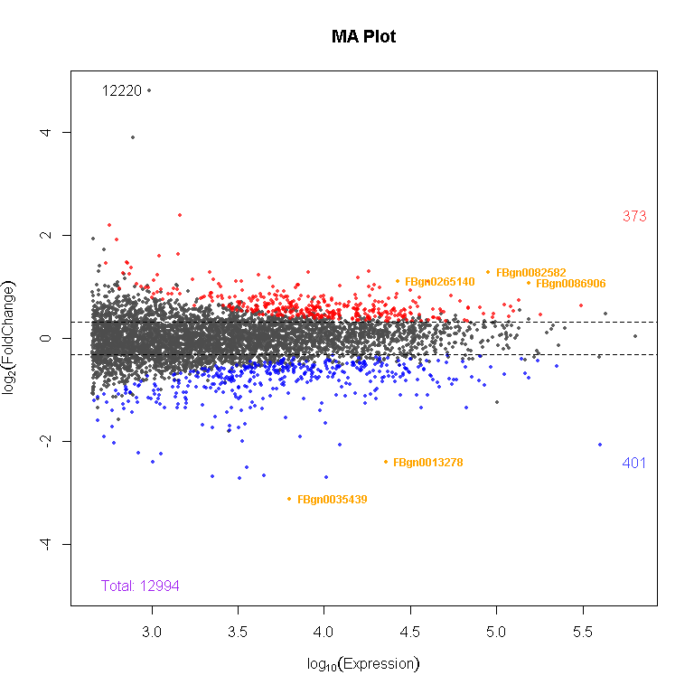

MA Plot

```
#> $Down
#> [1] 401
#>
#> $Up
#> [1] 373
#>
#> $No_Change
#> [1] 12220
```

```r
#Pull top significant genes to label and colour
genes<-rownames(res[order(res$padj),])[1:5]
#Make an MA plot
MA_Plot(res, title="MA Plot", p=0.05, FC=log(1.25,2), lab=genes, col=genes)
```

### volcanoPlot()

This function will generate a volcano plot from the *res* object. See *?volcanoPlot* to view all options

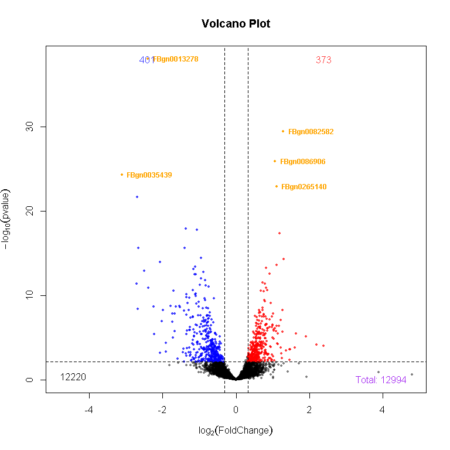

Volcano Plot diplaying upregulated (red) and downregulated (blue) genes

```
#> $Down
#> [1] 401
#>
#> $Up
#> [1] 373
#>
#> $No_Change
#> [1] 12220
```

```r
volcanoPlot(res, title="Volcano Plot", p=0.05, FC=log(1.25,2), lab=genes, col=genes)
```

### GO_GEM()

This function will run a gene ontology analysis using gprofiler2’s *gost()* function (Kolberg and Raudvere 2020) and output the results in a table (.txt), a .gem file (for compatibility with Cytoscape’s EnrichmentMap app (Merico et al. 2010; Reimand et al. 2019)), and two figures in a single .pdf displaying the top 10 enriched and top 10 significant terms. See *?GO_GEM* to view all options

```r
#Get downregulated gene names
genes<-rownames(subset(res, padj<0.05 & log2FoldChange < log(1.25, 2)))
#create output directory
dir.create("GO")
#Run GO analysis for Biological Process and output to folder "GO/GO_analysis*"
GO_GEM(genes, species="dmelanogaster", bg=rownames(res), source="GO:BP", prefix="GO/GO_analysis")
```

```
#> Single character list of genes provided...
#> Detected custom background input, domain scope is set to 'custom'
```

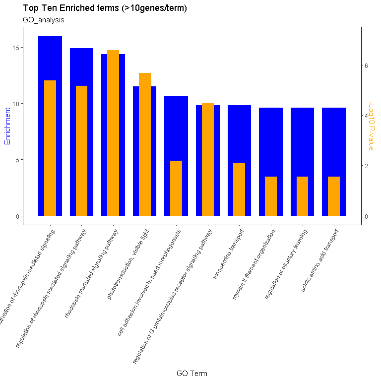

Top 10 Enriched GO terms - minimum 10 genes/term

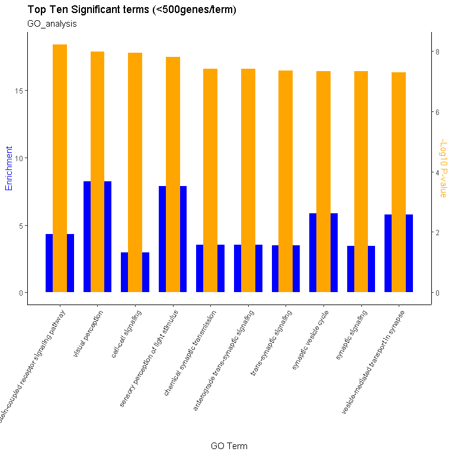

Top 10 Significant GO terms - maximum 500 genes/term

### zheat()

This function will generate a heatmap of z-score normalized gene counts using pheatmap (Kolde 2019). See *?zheat* to view all options

```
#> scaling to all genes...
#> pulling certain genes...
```

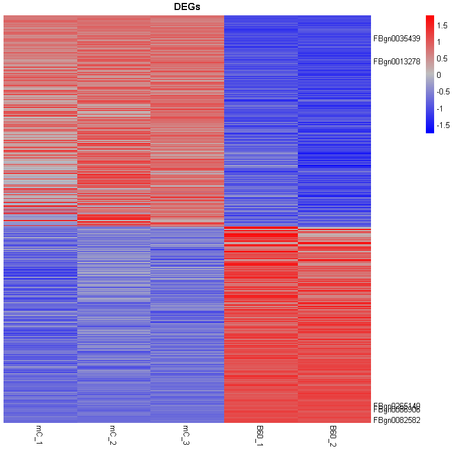

Heatmap of DEGs

```r
#Get the names of all differentially expressed genes
DEGs<-rownames(subset(res, padj<0.05 & abs(log2FoldChange)>log(1.25,2)))
#Pull top significant genes to label and colour
top_genes<-rownames(res[order(res$padj),])[1:5]
#Generate a heatmap
zheat(genes=DEGs, counts=norm_counts, conditions=cond, con="WT", title="DEGs", labgenes = top_genes)
```

### count_plot()

This function Will generate a violin plot of normalized gene expression for a specified group of genes. See *?count_plot* to view all options.

```
#> Using individual data points...
```

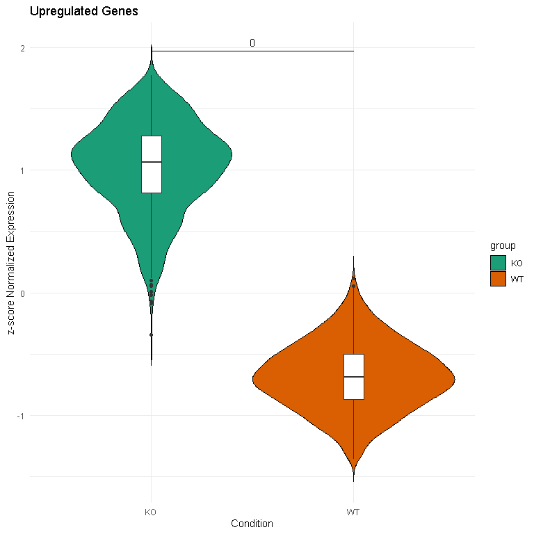

Violin plot comparing gene expression of upregulated genes between conditions

```r
#Check all upregulated genes
genes<-rownames(subset(res, padj<0.05 & log2FoldChange > log(1.25,2)))
#Compare gene expression between the two conditions using z-score normalized counts:
count_plot(counts=norm_counts, scaling="zscore", genes=genes, condition=cond, title="Upregulated Genes", compare=list(c("WT","KO")))
```